# Data605-Final project

Santosh Manjrekar

December 11, 2018

## Computational Mathematics

#### Problem-1

Pick X4 varibale as X and Y4 variable as Y.

```r
Y <- c(20.2, 18.6, 22.6, 11.4, 23.6, 24.0, 26.0, 26.8, 19.7, 22.7, 16.8, 20.2, 21.7, 20.9, 26.9, 16.3, 19.9, 15.5, 26.5, 21.7)
X <- c(9.3, 12.4, 19.9, 6.9, -1.0, 10.6, 6.4, 10.6, 1.2, 7.7, 15.5, 6.9, 13.7, 3.7, 4.4, 11.5, 4.2, 13.9, 12.9, 1.2)
```

### Probability.

Calculate as a minimum the below probabilities a through c. Assume the small letter “x” is estimated as the 3d quartile of the X variable, and the small letter “y” is estimated as the 1st quartile of the Y variable. Interpret the meaning of all probabilities.

```r
#Calculate 3rd quartile of x
(x <- quantile(X,0.75))
```

```
##    75%
## 12.525
```

```r
#calculate 1st quartile of y
(y <- quantile(Y,0.25))
```

```
##    25%
## 19.425
```

1. P(X > x| Y > y)

P(X > x| Y > y) = $\frac{(P X > x, Y >y)}{P(Y > y)}$ = $\frac{(P X > x, Y > y)}{P(Y > y)}$ = 0.2

```r
length(X[X>x & Y>y])/length(Y[Y>y])
```

```
## [1] 0.2
```

b.P(X>x , Y>y)

P(X > x| Y > y) = $\frac{(P X > x| Y >y)}{P(Y > y)}$ = 0.15

```r
length(X[X>x & Y>y])/length(Y)
```

```
## [1] 0.15
```

P(X < x| Y > y) = $\frac{(P( X < x, Y > y)}{P(Y > y)}$ = $\frac{P(< x)P(Y > y)}{P(Y > y)}$ = 0.8

```r
length(X[X<x & Y>y])/length(Y[Y>y])
```

```
## [1] 0.8
```

### In addition, make a table of counts as shown below.

```r
library(knitr)
a0 <- "<= 1st quartile"
a1 <- length(X[Y<=y & X<=x])
a2 <- length(X[Y>y & X<=x])
a3 <- a1 + a2

b0 <- "> 1st quartile"
b1 <- length(X[Y<=y & X>x])
b2 <- length(X[Y>y & X>x])
b3 <- b1 + b2

c0 <- "Total"
c1 <- a1 + b1
c2 <- a2 + b2
c3 <- c1 + c2

rownames = c()
colnames = c("y/x", "<= 3rd quartile", "> 3rd quartile", "Total")
kable(matrix(c(a0,a1,a2,a3,b0,b1,b2,b3,c0,c1,c2,c3),nrow = 3, byrow = TRUE, dimnames = list(rownames, colnames)))
```

| y/x | <= 3rd quartile | > 3rd quartile | Total |
| --- | --- | --- | --- |
| <= 1st quartile | 3 | 12 | 15 |
| > 1st quartile | 2 | 3 | 5 |
| Total | 5 | 15 | 20 |

### Does splitting the training data in this fashion make them independent?

Let A be the new variable counting those observations above the 1st quartile for X, and let B be the new variable counting those observations above the 1st quartile for Y. Does P(AB)=P(A)P(B)? Check mathematically, and then evaluate by running a Chi Square test for association.

```r
A <- X > x
B <- Y > y

probability_AB <- sum(A[B])
cat("P(AB) = ", probability_AB/length(X), "\n")
```

```
## P(AB) =  0.15
```

```r
probability_A <- sum(A)/length(X)
probability_B <- sum(B)/length(X)
cat("P(A)P(B) = ", probability_A*probability_B, "\n")
```

```
## P(A)P(B) =  0.1875
```

We conclude that P(AB)$\neq$P(A)P(B) so A and B are not independent.

```r
ptest <- chisq.test(rbind(x,y))
print(ptest)
```

```
##
##  Chi-squared test for given probabilities
##
## data:  rbind(x, y)
## X-squared = 1.4901, df = 1, p-value = 0.2222
```

#### Problem-2

### Descriptive and Inferential Statistics.

- Providing univariate descriptive statistics and appropriate plots for the training data set.

```r
suppressWarnings(suppressMessages(library(ggplot2)))
suppressWarnings(suppressMessages(library(corrplot)))
```

```r
train <- read.csv('https://raw.githubusercontent.com/santoshmanjrekar/data605/master/train.csv')
test <- read.csv('https://raw.githubusercontent.com/santoshmanjrekar/data605/master/test.csv')

cat("Training dataset count of rows and columns: ", dim(train))
```

```
## Training dataset count of rows and columns:  1460 81
```

```r
cat("Testing dataset count of rows and columns: ", dim(test))
```

```
## Testing dataset count of rows and columns:  1459 80
```

```r
#Let's see some sample training data
head(train)
```

```
##   Id MSSubClass MSZoning LotFrontage LotArea Street Alley LotShape
## 1  1         60       RL          65    8450   Pave  <NA>      Reg
## 2  2         20       RL          80    9600   Pave  <NA>      Reg
## 3  3         60       RL          68   11250   Pave  <NA>      IR1
## 4  4         70       RL          60    9550   Pave  <NA>      IR1
## 5  5         60       RL          84   14260   Pave  <NA>      IR1
## 6  6         50       RL          85   14115   Pave  <NA>      IR1
##   LandContour Utilities LotConfig LandSlope Neighborhood Condition1
## 1         Lvl    AllPub    Inside       Gtl      CollgCr       Norm
## 2         Lvl    AllPub       FR2       Gtl      Veenker      Feedr
## 3         Lvl    AllPub    Inside       Gtl      CollgCr       Norm
## 4         Lvl    AllPub    Corner       Gtl      Crawfor       Norm
## 5         Lvl    AllPub       FR2       Gtl      NoRidge       Norm
## 6         Lvl    AllPub    Inside       Gtl      Mitchel       Norm
##   Condition2 BldgType HouseStyle OverallQual OverallCond YearBuilt
```

[output cut: 76 more lines]

```r
#Lets check the summary statistics for training data
summary(train)
```

```
##        Id           MSSubClass       MSZoning     LotFrontage
##  Min.   :   1.0   Min.   : 20.0   C (all):  10   Min.   : 21.00
##  1st Qu.: 365.8   1st Qu.: 20.0   FV     :  65   1st Qu.: 59.00
##  Median : 730.5   Median : 50.0   RH     :  16   Median : 69.00
##  Mean   : 730.5   Mean   : 56.9   RL     :1151   Mean   : 70.05
##  3rd Qu.:1095.2   3rd Qu.: 70.0   RM     : 218   3rd Qu.: 80.00
##  Max.   :1460.0   Max.   :190.0                  Max.   :313.00
##                                                  NA's   :259
##     LotArea        Street      Alley      LotShape  LandContour
##  Min.   :  1300   Grvl:   6   Grvl:  50   IR1:484   Bnk:  63
##  1st Qu.:  7554   Pave:1454   Pave:  41   IR2: 41   HLS:  50
##  Median :  9478               NA's:1369   IR3: 10   Low:  36
##  Mean   : 10517                           Reg:925   Lvl:1311
##  3rd Qu.: 11602
##  Max.   :215245
##
##   Utilities      LotConfig    LandSlope   Neighborhood   Condition1
##  AllPub:1459   Corner : 263   Gtl:1382   NAmes  :225   Norm   :1260
##  NoSeWa:   1   CulDSac:  94   Mod:  65   CollgCr:150   Feedr  :  81
##                FR2    :  47   Sev:  13   OldTown:113   Artery :  48
##                FR3    :   4              Edwards:100   RRAn   :  26
##                Inside :1052              Somerst: 86   PosN   :  19
##                                          Gilbert: 79   RRAe   :  11
##                                          (Other):707   (Other):  15
##    Condition2     BldgType      HouseStyle   OverallQual
##  Norm   :1445   1Fam  :1220   1Story :726   Min.   : 1.000
##  Feedr  :   6   2fmCon:  31   2Story :445   1st Qu.: 5.000
##  Artery :   2   Duplex:  52   1.5Fin :154   Median : 6.000
##  PosN   :   2   Twnhs :  43   SLvl   : 65   Mean   : 6.099
##  RRNn   :   2   TwnhsE: 114   SFoyer : 37   3rd Qu.: 7.000
##  PosA   :   1                 1.5Unf : 14   Max.   :10.000
##  (Other):   2                 (Other): 19
##   OverallCond      YearBuilt     YearRemodAdd    RoofStyle
##  Min.   :1.000   Min.   :1872   Min.   :1950   Flat   :  13
##  1st Qu.:5.000   1st Qu.:1954   1st Qu.:1967   Gable  :1141
##  Median :5.000   Median :1973   Median :1994   Gambrel:  11
##  Mean   :5.575   Mean   :1971   Mean   :1985   Hip    : 286
##  3rd Qu.:6.000   3rd Qu.:2000   3rd Qu.:2004   Mansard:   7
##  Max.   :9.000   Max.   :2010   Max.   :2010   Shed   :   2
##
```

[output cut: 89 more lines]

```
##  GdPrv:  59   Gar2:   2   Min.   :    0.00   Min.   : 1.000
##  GdWo :  54   Othr:   2   1st Qu.:    0.00   1st Qu.: 5.000
##  MnPrv: 157   Shed:  49   Median :    0.00   Median : 6.000
##  MnWw :  11   TenC:   1   Mean   :   43.49   Mean   : 6.322
##  NA's :1179   NA's:1406   3rd Qu.:    0.00   3rd Qu.: 8.000
##                           Max.   :15500.00   Max.   :12.000
##
##      YrSold        SaleType    SaleCondition    SalePrice
##  Min.   :2006   WD     :1267   Abnorml: 101   Min.   : 34900
##  1st Qu.:2007   New    : 122   AdjLand:   4   1st Qu.:129975
##  Median :2008   COD    :  43   Alloca :  12   Median :163000
##  Mean   :2008   ConLD  :   9   Family :  20   Mean   :180921
##  3rd Qu.:2009   ConLI  :   5   Normal :1198   3rd Qu.:214000
##  Max.   :2010   ConLw  :   5   Partial: 125   Max.   :755000
##                 (Other):   9
```

- Provide a scatterplot matrix for at least two of the independent variables and the dependent variable.

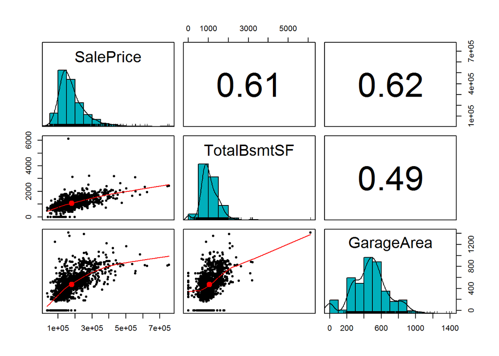

```r
#Lets have SalePrice as dependent variable and TotalBsmtSF and GarageArea as two independednt variables
#Scatter Plot Matrics
suppressWarnings(suppressMessages(library(psych)))
pairs.panels(train[,c('SalePrice','TotalBsmtSF','GarageArea')],
             method = "pearson", # correlation method
             hist.col = "#00AFBB",
             density = TRUE,  # show density plots
             ellipses = TRUE # show correlation ellipses
)
```

### Derive a correlation matrix for any THREE quantitative variables in the dataset.

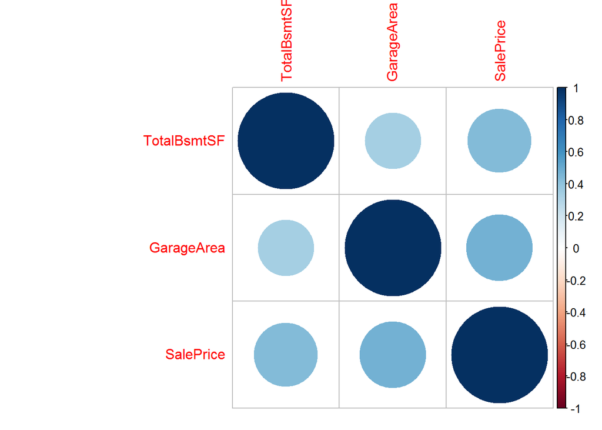

```r
df_matrix <- train[c("TotalBsmtSF","GarageArea", "SalePrice")]
corr_matrix <- cor(df_matrix, use="complete.obs", method="kendall")
corrplot(corr_matrix, method = "circle")
```

### Test the hypotheses that the correlations between each pairwise set of variables is 0 and provide a 80% confidence interval.

```r
#CI 80% for each variable
cor.test(train$TotalBsmtSF, train$SalePrice, method = c("pearson", "kendall", "spearman"), conf.level = 0.8)
```

```
##
##  Pearson's product-moment correlation
##
## data:  train$TotalBsmtSF and train$SalePrice
## t = 29.671, df = 1458, p-value < 2.2e-16
## alternative hypothesis: true correlation is not equal to 0
## 80 percent confidence interval:
##  0.5922142 0.6340846
## sample estimates:
##       cor
## 0.6135806
```

```r
#CI 80% = [0.60, 0.64]
cor.test(train$GarageArea, train$SalePrice, method = c("pearson", "kendall", "spearman"), conf.level = 0.8)
```

```
##
##  Pearson's product-moment correlation
##
## data:  train$GarageArea and train$SalePrice
## t = 30.446, df = 1458, p-value < 2.2e-16
## alternative hypothesis: true correlation is not equal to 0
## 80 percent confidence interval:
##  0.6024756 0.6435283
## sample estimates:
##       cor
## 0.6234314
```

```r
##
```

```r
#CI 80% = [0.46, 0.51]
cor.test(train$GarageArea, train$TotalBsmtSF, method = c("pearson", "kendall", "spearman"), conf.level = 0.8)
```

```
##
##  Pearson's product-moment correlation
##
## data:  train$GarageArea and train$TotalBsmtSF
## t = 21.272, df = 1458, p-value < 2.2e-16
## alternative hypothesis: true correlation is not equal to 0
## 80 percent confidence interval:
##  0.4606274 0.5118666
## sample estimates:
##       cor
## 0.4866655
```

### Discuss the meaning of your analysis. Would you be worried about family wise error? Why or why not?

P-value for each of case above is less than 0.05, we reject null hypothesis and accept alternative hypothesis that true correlation is not equal to 0 for each variable.

### Linear Algebra and Correlation.

+Invert your 3 x 3 correlation matrix from above. (This is known as the precision matrix and contains variance inflation factors on the diagonal.) Multiply the correlation matrix by the precision matrix, and then multiply the precision matrix by the correlation matrix. Conduct LU decomposition on the matrix.

```r
#Inverting matrix and multiplying
suppressWarnings(suppressMessages(library(matlib)))
```

```r
A <- cor(train[, c('TotalBsmtSF','GarageArea', 'SalePrice')], method = c("pearson", "kendall", "spearman"))
B <- inv(A)

AB = A * B
BA = B * A
I = diag(nrow(A))
AB
```

```
##             TotalBsmtSF GarageArea  SalePrice
## TotalBsmtSF   1.6507677 -0.1368536 -0.5139141
## GarageArea   -0.1368536  1.6836724 -0.5468188
## SalePrice    -0.5139141 -0.5468188  2.0607329
```

```r
BA
```

```
##
## [1,]  1.6507677 -0.1368536 -0.5139141
## [2,] -0.1368536  1.6836724 -0.5468188
## [3,] -0.5139141 -0.5468188  2.0607329
```

```r
I
```

```
##      [,1] [,2] [,3]
## [1,]    1    0    0
## [2,]    0    1    0
## [3,]    0    0    1
```

```r
#Note that AB = BA but not equal to I.

#LU decomposition
library(Matrix)
mm <- Matrix(A)
str(lum <- lu(mm))
```

```
## Formal class 'denseLU' [package "Matrix"] with 4 slots
##   ..@ x       : num [1:9] 1 0.487 0.614 0.487 0.763 ...
##   ..@ perm    : int [1:3] 1 2 3
##   ..@ Dimnames:List of 2
##   .. ..$ : chr [1:3] "TotalBsmtSF" "GarageArea" "SalePrice"
##   .. ..$ : chr [1:3] "TotalBsmtSF" "GarageArea" "SalePrice"
##   ..@ Dim     : int [1:2] 3 3
```

```r
elu <- expand(lum)
elu # three components: "L", "U", and "P", the permutation
```

```
## $L
## 3 x 3 Matrix of class "dtrMatrix" (unitriangular)
##      [,1]      [,2]      [,3]
## [1,] 1.0000000         .         .
## [2,] 0.4866655 1.0000000         .
## [3,] 0.6135806 0.4256308 1.0000000
##
## $U
## 3 x 3 Matrix of class "dtrMatrix"
##      [,1]      [,2]      [,3]
## [1,] 1.0000000 0.4866655 0.6135806
## [2,]         . 0.7631567 0.3248230
## [3,]         .         . 0.4852643
##
## $P
## 3 x 3 sparse Matrix of class "pMatrix"
##
## [1,] | . .
## [2,] . | .
## [3,] . . |
```

```r
elu$L %*% elu$U
```

```
## 3 x 3 Matrix of class "dgeMatrix"
##           [,1]      [,2]      [,3]
## [1,] 1.0000000 0.4866655 0.6135806
## [2,] 0.4866655 1.0000000 0.6234314
## [3,] 0.6135806 0.6234314 1.0000000
```

```r
(m2 <- with(elu, P %*% L %*% U)) # the same as 'mm'
```

```
## 3 x 3 Matrix of class "dgeMatrix"
##           [,1]      [,2]      [,3]
## [1,] 1.0000000 0.4866655 0.6135806
## [2,] 0.4866655 1.0000000 0.6234314
## [3,] 0.6135806 0.6234314 1.0000000
```

### Calculus-Based Probability & Statistics.

Many times, it makes sense to fit a closed form distribution to data. Select a variable in the Kaggle.com training dataset that is skewed to the right, shift it so that the minimum value is absolutely above zero if necessary. Then load the MASS package and run fitdistr to fit an exponential probability density function. (See https://stat.ethz.ch/R-manual/R-devel/library/MASS/html/fitdistr.html ). Find the optimal value of ??? for this distribution, and then take 1000 samples from this exponential distribution using this value (e.g., rexp(1000, ???)). Plot a histogram and compare it with a histogram of your original variable. Using the exponential pdf, find the 5th and 95th percentiles using the cumulative distribution function (CDF). Also generate a 95% confidence interval from the empirical data, assuming normality. Finally, provide the empirical 5th percentile and 95th percentile of the data. Discuss.

```r
#From summary of train data, we pick any variable that has median < mean.
#BsmtUnfSF has median < mean. Let's choose this.
summary(train$BsmtUnfSF)
```

```
##    Min. 1st Qu.  Median    Mean 3rd Qu.    Max.
##     0.0   223.0   477.5   567.2   808.0  2336.0
```

```r
#To me, BsmtUnfSF = 0 does not make sense. Let's filter these out
suppressWarnings(suppressMessages(library(MASS)))
suppressWarnings(suppressMessages(library(rcompanion)))
Turbidity = train$BsmtUnfSF
Turbidity = Turbidity[Turbidity>0]
Turbidity
```

[output not shown]

[output cut: 89 more lines]

```r
#Let's plot normal histogram of filtered data
plotNormalHistogram(Turbidity)
```

[output not shown]

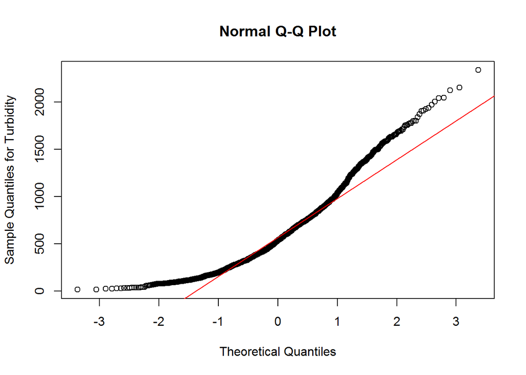

```r
qqnorm(Turbidity,
       ylab="Sample Quantiles for Turbidity")
qqline(Turbidity,
       col="red")
```

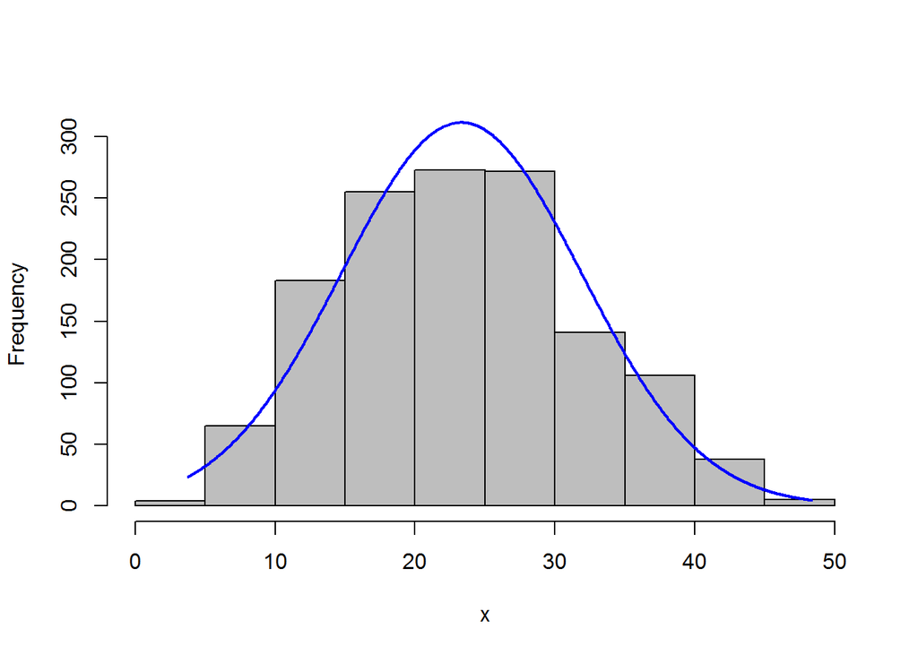

```r
#The data is indeed postively skewed and QQ plot shows the data has exponential shape.

#Square root transformation
T_sqrt = sqrt(Turbidity)
plotNormalHistogram(T_sqrt)
```

```r
summary(T_sqrt)
```

```
##    Min. 1st Qu.  Median    Mean 3rd Qu.    Max.
##   3.742  16.971  23.152  23.309  29.039  48.332
```

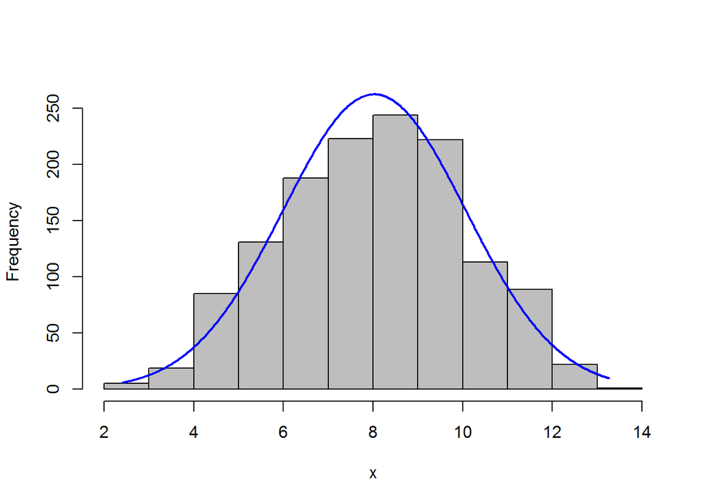

```r
#Cube -- from the shape, it looks like cube works the best
T_cub = sign(Turbidity) * abs(Turbidity)^(1/3)   # Avoid complex numbers
plotNormalHistogram(T_cub)
```

```r
summary(T_cub)
```

```
##    Min. 1st Qu.  Median    Mean 3rd Qu.    Max.
##   2.410   6.604   8.123   8.029   9.448  13.269
```

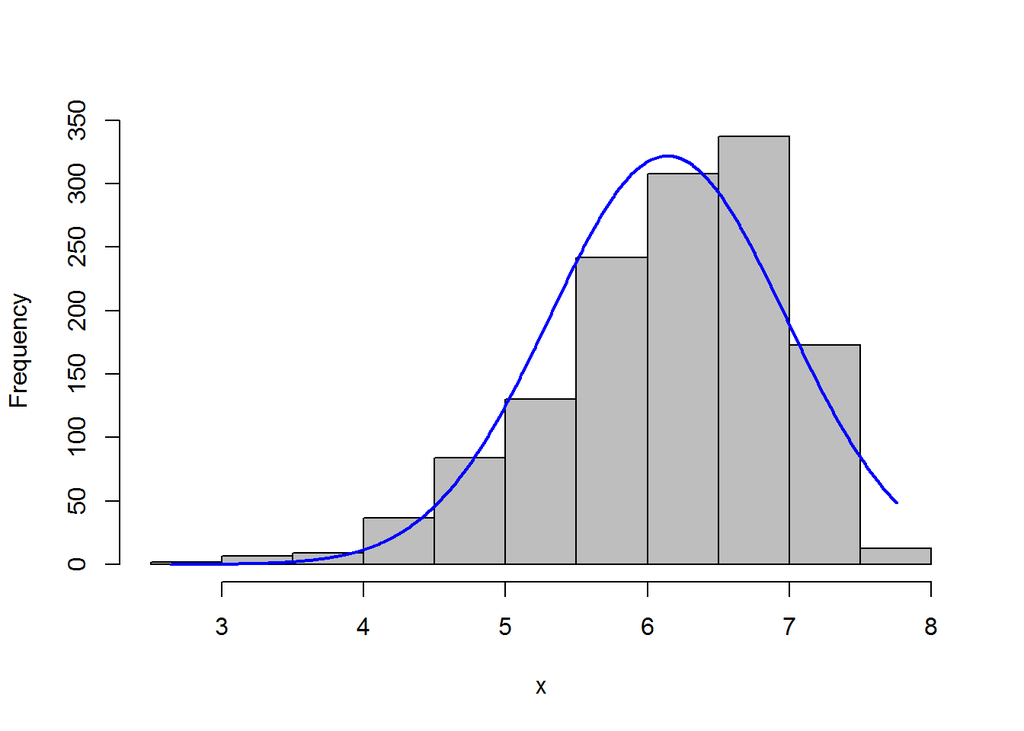

```r
#Log
T_log = log(Turbidity)
plotNormalHistogram(T_log)
```

```r
summary(T_log)
```

```
##    Min. 1st Qu.  Median    Mean 3rd Qu.    Max.
##   2.639   5.663   6.284   6.142   6.737   7.756
```

```r
#Testing fit distr
estimate_original <- fitdistr(Turbidity, "exponential")
estimate_sqrt <- fitdistr(T_sqrt, "exponential")
estimate_cube <- fitdistr(T_cub, "exponential")
estimate_log <- fitdistr(T_log, "exponential")


#Let's compare each estimate


#original vs original_exp

#Skewness
Turbidity_exp = rexp(1000,rate = estimate_original$estimate)

plotNormalHistogram(Turbidity)
```

[output not shown]

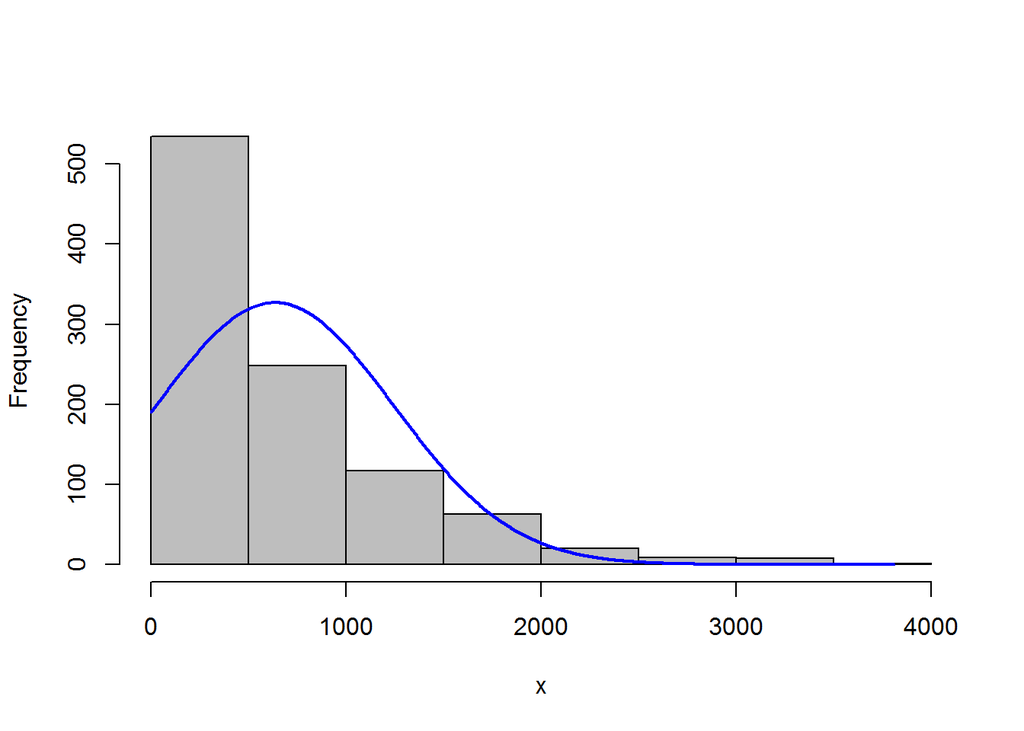

```r
plotNormalHistogram(Turbidity_exp)
```

```r
#quantile 5%, 95%
quantile(Turbidity, c(.05, .95))
```

```
##   5%  95%
##  100 1489
```

```r
quantile(Turbidity_exp, c(.05, .95))
```

```
##         5%        95%
##   28.83454 1830.83197
```

```r
summary(Turbidity)
```

```
##    Min. 1st Qu.  Median    Mean 3rd Qu.    Max.
##    14.0   288.0   536.0   617.1   843.2  2336.0
```

```r
summary(Turbidity_exp)
```

```
##     Min.  1st Qu.   Median     Mean  3rd Qu.     Max.
##    0.566  186.525  453.907  635.883  897.529 3809.657
```

```r
#original vs original_sqrt_exp

#Skewness
T_sqrt_exp = rexp(1000,rate = estimate_sqrt$estimate)

plotNormalHistogram(Turbidity)
```

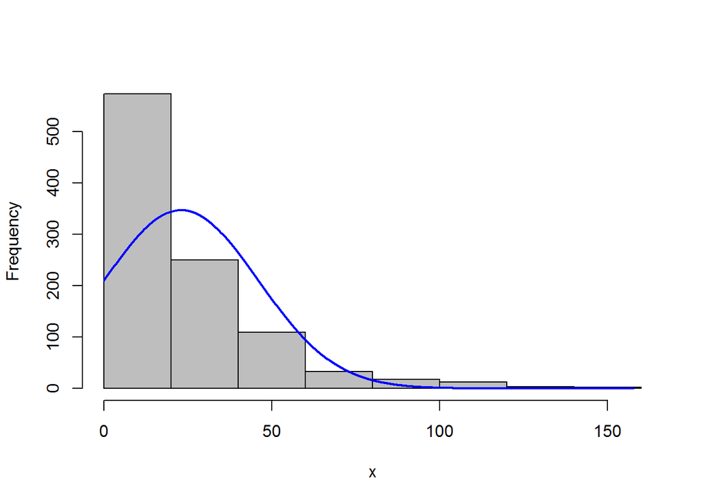

```r
plotNormalHistogram(T_sqrt_exp)
```

```r
#quantile 5%, 95%
quantile(Turbidity, c(.05, .95))
```

```
##   5%  95%
##  100 1489
```

```r
quantile(T_sqrt_exp, c(.05, .95))
```

```
##       5%      95%
##  1.14191 67.36656
```

```r
#original vs original_cube_exp

#Skewness
T_cube_exp = rexp(1000,rate = estimate_cube$estimate)

plotNormalHistogram(Turbidity)
```

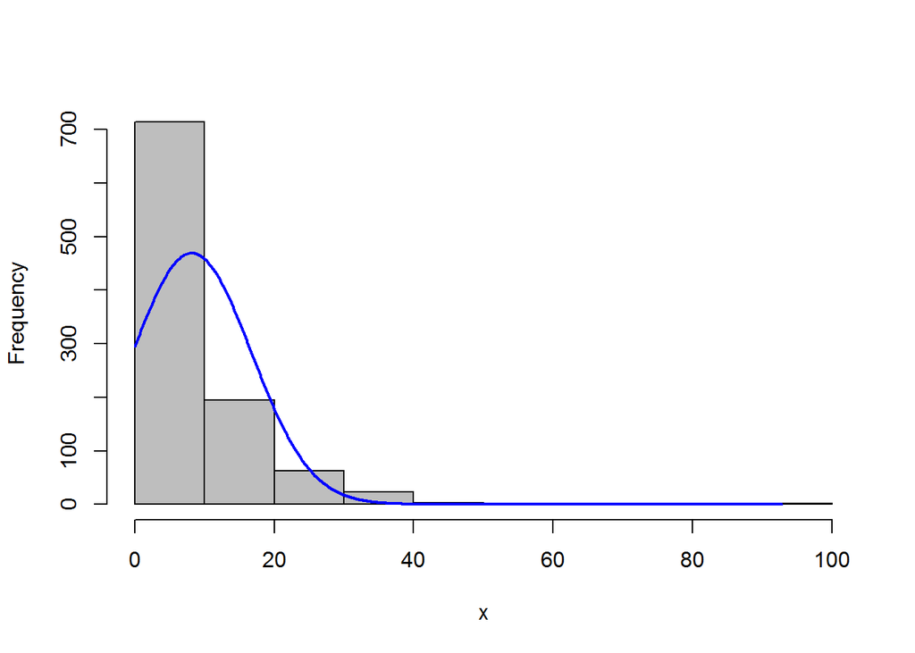

```r
plotNormalHistogram(T_cube_exp)
```

```r
#quantile 5%, 95%
quantile(Turbidity, c(.05, .95))
```

```
##   5%  95%
##  100 1489
```

```r
quantile(T_cube_exp, c(.05, .95))
```

```
##         5%        95%
##  0.4800923 24.8889857
```

```r
#original vs original_log_exp

#Skewness
T_log_exp = rexp(1000,rate = estimate_log$estimate)

plotNormalHistogram(Turbidity)
```

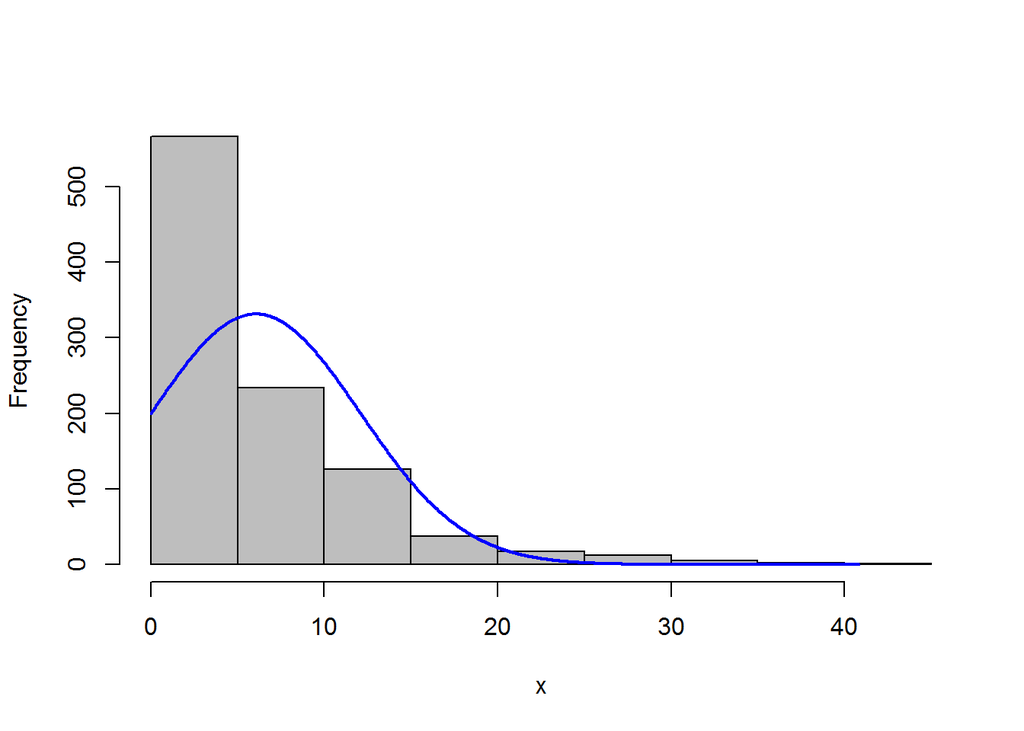

```r
plotNormalHistogram(T_log_exp)
```

```r
#quantile 5%, 95%
quantile(Turbidity, c(.05, .95))
```

```
##   5%  95%
##  100 1489
```

```r
quantile(T_log_exp, c(.05, .95))
```

```
##         5%        95%
##  0.3229636 17.5868347
```

In conclusion, we can see that exponential density function transform original datasets, whether they were transformed in to log, sqrt, cube or stayed original, into exponential shape. Note that datasets applied with exponential function are more heavily skewed to the right than original datasets, according to Normal Histogram.

### Modeling

Build some type of multiple regression model and submit your model to the competition board. Provide your complete model summary and results with analysis. Report your Kaggle.com user name and score.

```r
regression <- lm(SalePrice ~ LotArea + LotFrontage + BldgType + OverallQual + BsmtQual +  GarageArea + GarageYrBlt + GrLivArea + TotalBsmtSF, data = train)
summary(regression)
```

```
##
## Call:
## lm(formula = SalePrice ~ LotArea + LotFrontage + BldgType + OverallQual +
##     BsmtQual + GarageArea + GarageYrBlt + GrLivArea + TotalBsmtSF,
##     data = train)
##
## Residuals:
##     Min      1Q  Median      3Q     Max
## -488971  -17498    -706   15316  261798
##
## Coefficients:
##                  Estimate Std. Error t value Pr(>|t|)
## (Intercept)    -2.962e+05  1.460e+05  -2.028 0.042807 *
## LotArea         7.263e-01  1.618e-01   4.488 7.94e-06 ***
## LotFrontage    -1.650e+02  6.425e+01  -2.569 0.010338 *
## BldgType2fmCon -1.904e+04  8.886e+03  -2.142 0.032395 *
## BldgTypeDuplex -2.797e+04  8.208e+03  -3.407 0.000680 ***
## BldgTypeTwnhs  -3.152e+04  7.306e+03  -4.313 1.75e-05 ***
## BldgTypeTwnhsE -1.708e+04  4.922e+03  -3.471 0.000539 ***
## OverallQual     2.095e+04  1.463e+03  14.321  < 2e-16 ***
## BsmtQualFa     -6.976e+04  9.359e+03  -7.453 1.86e-13 ***
## BsmtQualGd     -5.056e+04  4.601e+03 -10.988  < 2e-16 ***
## BsmtQualTA     -6.244e+04  5.921e+03 -10.545  < 2e-16 ***
## GarageArea      3.940e+01  9.245e+00   4.262 2.20e-05 ***
## GarageYrBlt     1.510e+02  7.417e+01   2.036 0.042034 *
## GrLivArea       4.606e+01  3.134e+00  14.696  < 2e-16 ***
## TotalBsmtSF     1.997e+01  3.831e+00   5.214 2.21e-07 ***
## ---
## Signif. codes:  0 '***' 0.001 '**' 0.01 '*' 0.05 '.' 0.1 ' ' 1
##
## Residual standard error: 38490 on 1088 degrees of freedom
##   (357 observations deleted due to missingness)
## Multiple R-squared:  0.7893, Adjusted R-squared:  0.7866
## F-statistic: 291.1 on 14 and 1088 DF,  p-value: < 2.2e-16
```

```r
new_regression <- update(regression, . ~ . - GarageYrBlt)
summary(new_regression)
```

```
##
## Call:
## lm(formula = SalePrice ~ LotArea + LotFrontage + BldgType + OverallQual +
##     BsmtQual + GarageArea + GrLivArea + TotalBsmtSF, data = train)
##
## Residuals:
##     Min      1Q  Median      3Q     Max
## -486529  -16814    -782   15762  264867
##
## Coefficients:
##                  Estimate Std. Error t value Pr(>|t|)
## (Intercept)     1.242e+04  1.061e+04   1.171 0.241819
## LotArea         7.101e-01  1.587e-01   4.475 8.39e-06 ***
## LotFrontage    -1.676e+02  6.158e+01  -2.722 0.006577 **
## BldgType2fmCon -1.787e+04  7.715e+03  -2.316 0.020731 *
## BldgTypeDuplex -2.079e+04  6.845e+03  -3.037 0.002441 **
## BldgTypeTwnhs  -2.740e+04  6.779e+03  -4.042 5.66e-05 ***
## BldgTypeTwnhsE -1.685e+04  4.791e+03  -3.516 0.000455 ***
## OverallQual     2.021e+04  1.364e+03  14.815  < 2e-16 ***
## BsmtQualFa     -7.946e+04  8.559e+03  -9.284  < 2e-16 ***
## BsmtQualGd     -5.292e+04  4.494e+03 -11.776  < 2e-16 ***
## BsmtQualTA     -7.070e+04  5.382e+03 -13.135  < 2e-16 ***
## GarageArea      4.269e+01  6.763e+00   6.312 3.91e-10 ***
## GrLivArea       4.410e+01  2.906e+00  15.175  < 2e-16 ***
## TotalBsmtSF     2.124e+01  3.705e+00   5.733 1.26e-08 ***
## ---
## Signif. codes:  0 '***' 0.001 '**' 0.01 '*' 0.05 '.' 0.1 ' ' 1
##
## Residual standard error: 38070 on 1156 degrees of freedom
##   (290 observations deleted due to missingness)
## Multiple R-squared:  0.7941, Adjusted R-squared:  0.7918
## F-statistic:   343 on 13 and 1156 DF,  p-value: < 2.2e-16
```

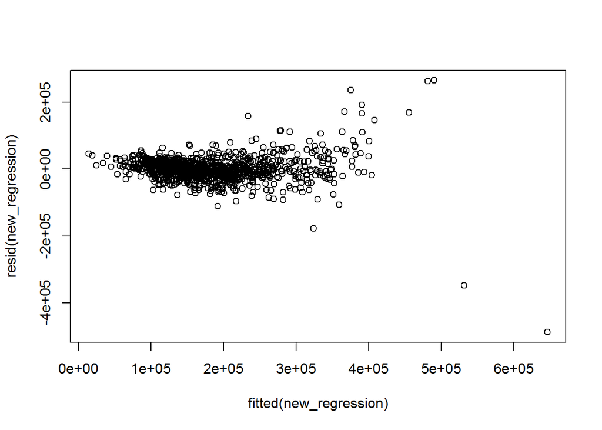

```r
plot(fitted(new_regression), resid(new_regression))
```

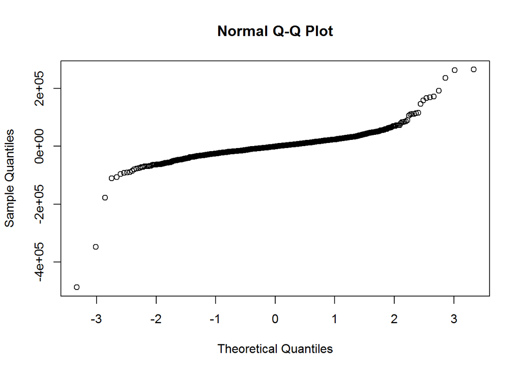

```r
qqnorm(resid(new_regression))
```

```r
SalePrice <- predict(new_regression, newdata = test)
Id <- 1461:2919
prediction <- data.frame(Id, SalePrice)
head(prediction)
```

```
##     Id SalePrice
## 1 1461  127023.8
## 2 1462  159688.1
## 3 1463  170089.1
## 4 1464  167458.5
## 5 1465  205908.6
## 6 1466  183259.6
```

```r
summary(prediction)
```

```
##        Id         SalePrice
##  Min.   :1461   Min.   : -2620
##  1st Qu.:1826   1st Qu.:127314
##  Median :2190   Median :162729
##  Mean   :2190   Mean   :178581
##  3rd Qu.:2554   3rd Qu.:214093
##  Max.   :2919   Max.   :603124
##                 NA's   :265
```

```r
prediction$SalePrice[is.na(prediction$SalePrice)] <- 0
write.csv(prediction, "kaggle_submission.csv",row.names=F)
```

Kaggle Username:santoshmmanjrekar

Kaggle Score : 5.05

Kaggle Submitted File - https://github.com/santoshmanjrekar/data605/blob/master/kaggle_submission.csv